# Retrieve economic data using `quantmod`

SW

2024-09-22

Various financial and economic data can be retrieved by using `quantmod` library. Of course, we need to load the library first:

```r
# Load the 'quantmod' library
library(quantmod)
```

## Retrieve stock prices from Yahoo Finance

### For stocks with stock tickers beginning with letter

We demonstrate the method by obtaining the stock prices of Apple Inc. (AAPL).

```r
# Get stock prices of Apple
getSymbols("AAPL", from=(Sys.Date()-730), to=Sys.Date())
```

We can observe the loaded data with the following commands:

```r
# The size of the loaded dataset
dim(AAPL)
```

```
## [1] 501   6
```

```r
# The first 6 rows of the dataset
head(AAPL)
```

```
##            AAPL.Open AAPL.High AAPL.Low AAPL.Close AAPL.Volume AAPL.Adjusted
## 2022-09-23    151.19    151.47   148.56     150.43    96029900      148.7815
## 2022-09-26    149.66    153.77   149.64     150.77    93339400      149.1178
## 2022-09-27    152.74    154.72   149.95     151.76    84442700      150.0970
## 2022-09-28    147.64    150.64   144.84     149.84   146691400      148.1980
## 2022-09-29    146.10    146.72   140.68     142.48   128138200      140.9186
## 2022-09-30    141.28    143.10   138.00     138.20   124925300      136.6855
```

```r
# The last 6 rows of the dataset
tail(AAPL)
```

```
##            AAPL.Open AAPL.High AAPL.Low AAPL.Close AAPL.Volume AAPL.Adjusted
## 2024-09-13    223.58    224.04   221.91     222.50    36766600        222.50
## 2024-09-16    216.54    217.22   213.92     216.32    59357400        216.32
## 2024-09-17    215.75    216.90   214.50     216.79    45519300        216.79
## 2024-09-18    217.55    222.71   217.54     220.69    59894900        220.69
## 2024-09-19    224.99    229.82   224.63     228.87    66781300        228.87
## 2024-09-20    229.97    233.09   227.62     228.20   318582200        228.20
```

We can create a plot of closing prices and trading volumes with the following commands:

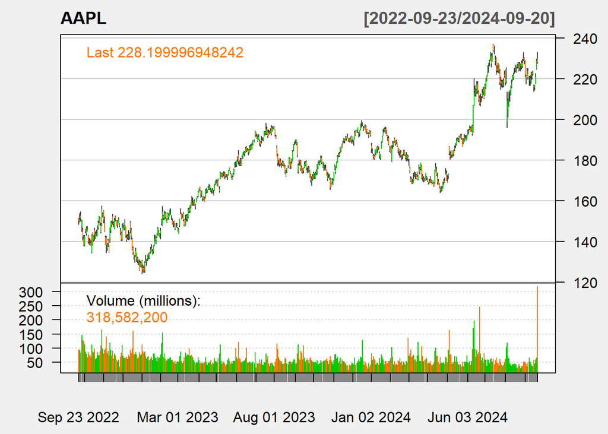

```r
# Create time plot
# The option 'theme="white" set the background of the time plot
# The default of this option is "black"
chartSeries(AAPL, theme = "white")
```

### For stocks with stock tickers beginning with number

We need to set the option `auto.assign=FALS` it the stock tickers beginning with a number when calling `getSymbols()`. This will allow you to assign the data returned to a variable name of your choice.

We demonstrate the method by obtaining the stock prices of HSBC (0005).

```r
# Get HSBC stock price
HSBC.HK <- getSymbols("0005.HK",from="2022-08-17", to=Sys.Date(),
                      auto.assign = FALSE)
```

We can observe the loaded data with the following commands:

```r
# The size of the loaded data set
dim(HSBC.HK)
```

```
## [1] 515   6
```

```r
# The last 3 rows of data
tail(HSBC.HK, n = 3)
```

```
##            0005.HK.Open 0005.HK.High 0005.HK.Low 0005.HK.Close 0005.HK.Volume
## 2024-09-17        67.40        68.25       67.25         68.15       19036822
## 2024-09-19        68.00        68.90       67.95         68.55       22332114
## 2024-09-20        68.85        69.40       68.80         68.95       29810317
##            0005.HK.Adjusted
## 2024-09-17            68.15
## 2024-09-19            68.55
## 2024-09-20            68.95
```

We can create a plot of closing prices and trading volumes with the following commands:

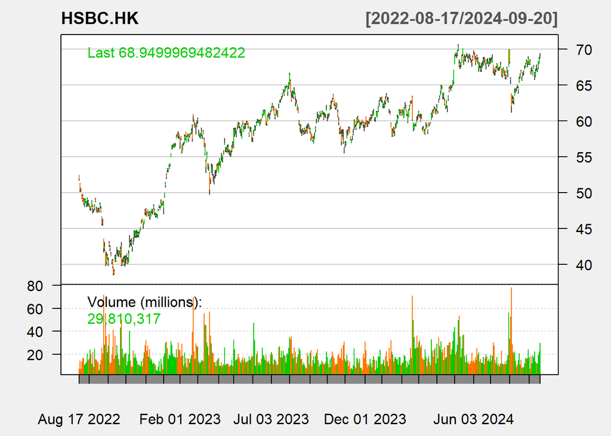

```r
# Create time plot
chartSeries(HSBC.HK,theme="white")
```

We now try another example in getting stock prices of Hon Hai Precision Industry Co., Ltd. (2317.TW) listed in Taiwan Stock Exchange.

```r
# Get Hon Hai Precision Industry Co., Ltd
Honhai.TW <- getSymbols("2317.TW",from=(Sys.Date()-730), to=Sys.Date(),
                      auto.assign = FALSE)
tail(Honhai.TW, n = 3)
```

```
##            2317.TW.Open 2317.TW.High 2317.TW.Low 2317.TW.Close 2317.TW.Volume
## 2024-09-18        179.0        179.5       173.5         174.0       76540029
## 2024-09-19        174.5        176.5       173.0         176.5       41446153
## 2024-09-20        180.0        182.0       177.0         177.0       81520029
##            2317.TW.Adjusted
## 2024-09-18            174.0
## 2024-09-19            176.5
## 2024-09-20            177.0
```

We can compare performance of the stocks by the following commands:

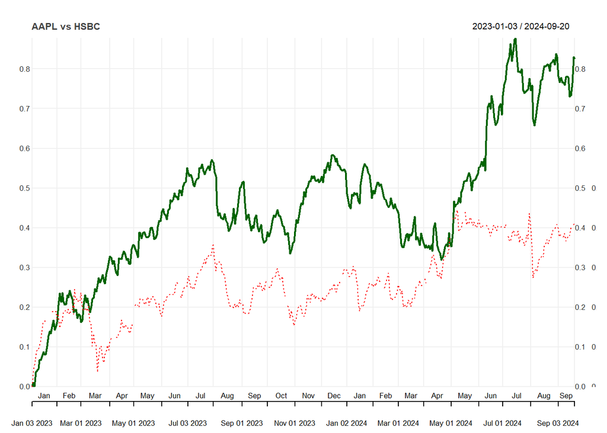

```r
normalise_series <- function(xdat) xdat / coredata(xdat)[1]
window <- "2023/"
mytheme <- chart_theme()
mytheme$col$line.col <- "darkgreen"
TA <- chart_Series(normalise_series(Cl(AAPL)[window])-1, name = "AAPL vs HSBC", legend = "AAPL", theme = mytheme)
TA <- add_TA(normalise_series(Cl(HSBC.HK)[window])-1, on = 1, legend = "HSBC", col = "red", lty = 3)
TA
```

## Retrieve financial information using `getQuote`

Please see the following example:

```r
what_metrics <- yahooQF(c("Name",
                          "Currency",
                          "Last Trade (Price Only)",
                          "P/E Ratio",
                          "Dividend Yield"))
tickers <- c("AAPL", "0005.HK")
getQuote(tickers, what = what_metrics)
```

```
##                  Trade Time          Name Currency   Last P/E Ratio Dividend Yield
## AAPL    2024-09-21 04:00:03    Apple Inc.      USD 228.20 34.733635    0.004238214
## 0005.HK 2024-09-20 16:08:30 HSBC HOLDINGS      HKD  68.95  7.627212    0.008898614
```

You can get the list of available financial information by typing:

```r
yahooQF()
```

## Retrieve daily interest rate of 10-year treasures notes

```r
# Retrieve daily interest rate of 10-year treasures notes
# These are interest rates from the Chicago Board Options Exchange (CBOE)
# obtained from Yahoo Finance
getSymbols("^TNX")
```

```
## [1] "TNX"
```

```r
#See the size of the loaded data set
dim(TNX)
```

```
## [1] 4623    6
```

```r
#See the first 6 row of data
#Note that the trading volume is 0
head(TNX)
```

```
##            TNX.Open TNX.High TNX.Low TNX.Close TNX.Volume TNX.Adjusted
## 2007-01-03    4.658    4.692   4.636     4.664          0        4.664
## 2007-01-04    4.656    4.662   4.602     4.618          0        4.618
## 2007-01-05    4.587    4.700   4.583     4.646          0        4.646
## 2007-01-08    4.668    4.678   4.654     4.660          0        4.660
## 2007-01-09    4.660    4.670   4.644     4.656          0        4.656
## 2007-01-10    4.666    4.700   4.660     4.682          0        4.682
```

```r
#See the last 6 row of data
tail(TNX)
```

```
##            TNX.Open TNX.High TNX.Low TNX.Close TNX.Volume TNX.Adjusted
## 2024-09-13    3.659    3.676   3.644     3.650          0        3.650
## 2024-09-16    3.638    3.663   3.618     3.621          0        3.621
## 2024-09-17    3.614    3.655   3.603     3.642          0        3.642
## 2024-09-18    3.681    3.696   3.638     3.685          0        3.685
## 2024-09-19    3.719    3.768   3.711     3.740          0        3.740
## 2024-09-20    3.734    3.764   3.715     3.728          0        3.728
```

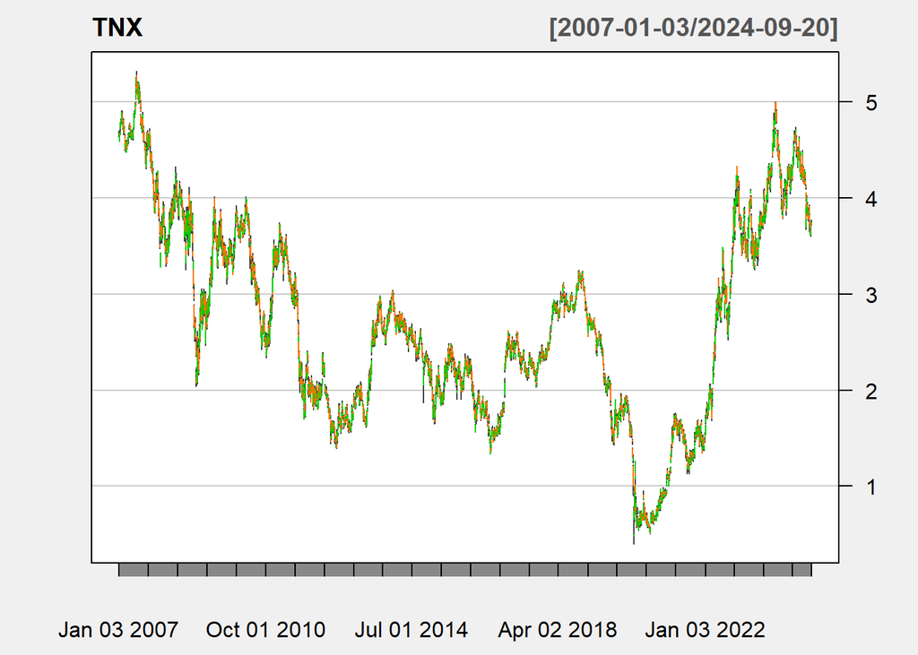

```r
#Obtain time plot of daily interest rates without trading volume
#The subcommand TA=NULL is used to omit the time plot of volume
chartSeries(TNX,theme="white",TA=NULL)
```

## Retrieve economic data from the Federal Reserve Economic Data (FRED) of Federal Reserve Bank of St. Louis

```r
# Retrieve financial data from FRED
# Load monthly unemployment rate from FRED
getSymbols("UNRATE", src="FRED")
```

```
## [1] "UNRATE"
```

```r
#See the size of the loaded data set
dim(UNRATE)
```

```
## [1] 920   1
```

```r
#See the first 6 row of data
head(UNRATE)
```

```
##            UNRATE
## 1948-01-01    3.4
## 1948-02-01    3.8
## 1948-03-01    4.0
## 1948-04-01    3.9
## 1948-05-01    3.5
## 1948-06-01    3.6
```

```r
#See the last 6 row of data
tail(UNRATE)
```

```
##            UNRATE
## 2024-03-01    3.8
## 2024-04-01    3.9
## 2024-05-01    4.0
## 2024-06-01    4.1
## 2024-07-01    4.3
## 2024-08-01    4.2
```

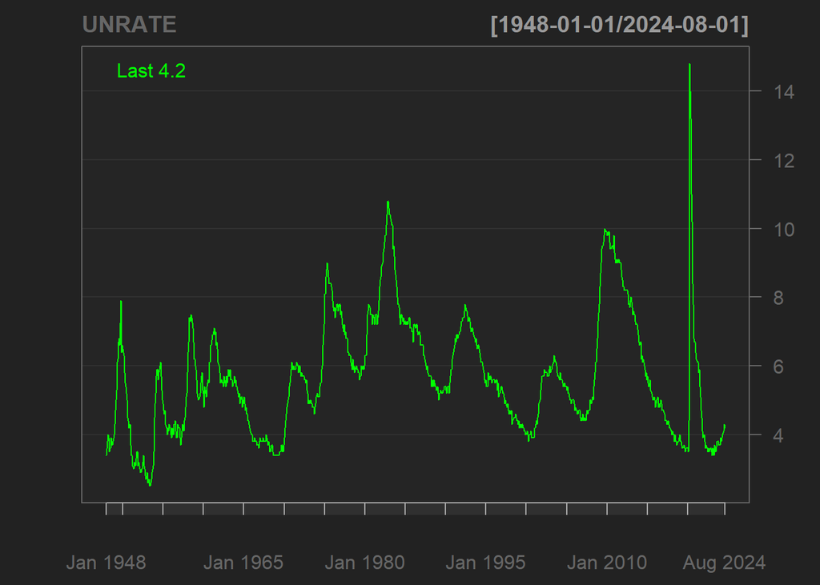

```r
#Obtain time plot of monthly U.S. unemployment rates
#The subcommand theme="white" set the background of the time plot
#The default is black
chartSeries(UNRATE)
```